# min-min Least Squares Classifier

Jesse H. Krijthe

01 July, 2016

# min-min in the contrastive setting

While Maximum Contrastive Pessimistic Likelihood estimation (MCPL), considers
$$\min_{\mathbf{w}} \max_{\mathbf{y}_\text{u} \in {[0,1]}^U} \left\lVert
\mathbf{X}_\text{e} \mathbf{w} - \begin{bmatrix} \mathbf{y} \\ \mathbf{y}_\text{e} \end{bmatrix} \right\rVert
^2 - \left\lVert
\mathbf{X}_\text{e} \mathbf{w}_\text{sup} - \begin{bmatrix} \mathbf{y} \\ \mathbf{y}_\text{e} \end{bmatrix} \right\rVert
^2$$
we can also let go of conservatism by considering the best possible labeling, instead of the worst possible labeling:
$$\min_{\mathbf{w}} \min_{\mathbf{y}_\text{u} \in {[0,1]}^U} \left\lVert
\mathbf{X}_\text{e} \mathbf{w} - \begin{bmatrix} \mathbf{y} \\ \mathbf{y}_\text{e} \end{bmatrix} \right\rVert
^2 - \left\lVert
\mathbf{X}_\text{e} \mathbf{w}_\text{sup} - \begin{bmatrix} \mathbf{y} \\ \mathbf{y}_\text{e} \end{bmatrix} \right\rVert
^2$$

Are these two types the same?

In the following, let $m$ be the numerical label for class 1 and $n$ be the numerical label for class 2.

## Type 1

Contrastive with responsibilities as variables
$$\begin{align}
J(\mathbf{w},\mathbf{q}) = & \sum_{i=1}^{L} \mathbf{w}^\top \mathbf{x}_i \mathbf{x}_i^\top \mathbf{w} - 2 y_i \mathbf{x}_i^\top \mathbf{w} + y_i^2 + \sum_{j=1}^{U} q_i (\mathbf{w}^\top \mathbf{x}_j \mathbf{x}_j^\top \mathbf{w} - 2 m \mathbf{x}_j^\top \mathbf{w} + m^2) + (1-q_i) (\mathbf{w}^\top \mathbf{x}_j \mathbf{x}_j^\top \mathbf{w}^\top - 2 n \mathbf{x}_j^\top \mathbf{w} + n^2) \\
& - \sum_{i=1}^{L} \mathbf{w}_\text{sup}^\top \mathbf{x}_i \mathbf{x}_i^\top \mathbf{w}_\text{sup} - 2 y_i \mathbf{x}_i^\top \mathbf{w}_\text{sup} + y_i^2 - \sum_{j=1}^{U} q_i (\mathbf{w}_\text{sup}^\top \mathbf{x}_j \mathbf{x}_j^\top \mathbf{w}_\text{sup} - 2 m \mathbf{x}_j^\top \mathbf{w}_\text{sup} + m^2) + (1-q_i) (\mathbf{w}_\text{sup}^\top \mathbf{x}_j \mathbf{x}_j^\top \mathbf{w}_\text{sup}^\top - 2 n \mathbf{x}_j^\top \mathbf{w}_\text{sup} + n^2)
\end{align}$$
which gives the following gradient:
$$\frac{\nabla J}{\nabla \mathbf{w}} = 2 \mathbf{X}^\top \mathbf{X} \mathbf{w} - 2 \mathbf{X}^\top \mathbf{y} + 2 \mathbf{X}_\text{u}^\top \mathbf{X}_\text{u} \mathbf{w} - 2 \mathbf{X}_\text{u} (\mathbf{q} m - \mathbf{q} n +n$$
$$\begin{align}
\frac{\nabla J}{\nabla q_i} = & 2 m \mathbf{x}_j^\top \mathbf{w}_\text{sup} - 2 m \mathbf{x}_j^\top \mathbf{w} + 2 n \mathbf{x}_j^\top \mathbf{w} - 2 n \mathbf{x}_j^\top \mathbf{w}_\text{sup} \\
= & -2 (\mathbf{x}_j^\top \mathbf{w} - \mathbf{x}_j^\top \mathbf{w}_\text{sup}) (m-n)
\end{align}$$
We now consider the second derivatives:
$$\frac{\nabla J}{\nabla \mathbf{w} \nabla \mathbf{w}} = 2 \mathbf{X}_\text{e}^\top \mathbf{X}_\text{e}$$

$$\frac{\nabla J}{\nabla \mathbf{q} \nabla \mathbf{q}} = 0$$

$$\frac{\nabla J}{\nabla \mathbf{w} \nabla \mathbf{q}} = -2 (m-n) \mathbf{X}_\text{u}$$

which gives the following hessian:
$$H=\begin{bmatrix}
2 \mathbf{X}_\text{e}^\top \mathbf{X}_\text{e} &
-2 (m-n) \mathbf{X}_\text{u}^\top \\
-2 (m-n) \mathbf{X}_\text{u} &
\mathbf{0}
\end{bmatrix}$$
So for the problem to be convex we would need:
$$2 \mathbf{z}^\top_1 \mathbf{X}_\text{e}^\top \mathbf{X}_\text{e} \mathbf{z}_1 - 2 (m-n) \mathbf{z}_2^\top \mathbf{X}_\text{u} \mathbf{z}_1 \geq 0$$
For all $\mathbf{z} \in \mathbb{R}^{d+U}$. This seems unlikely.

## Type 2

Contrastive with labels as variables:
$$\begin{align}
J(\mathbf{w},\mathbf{u}) = & \sum_{i=1}^{L} ( \mathbf{w}^\top \mathbf{x}_i \mathbf{x}_i^\top \mathbf{w} - 2 y_i \mathbf{x}_i^\top \mathbf{w} + y_i^2 ) + \sum_{j=1}^{U} (\mathbf{w}^\top \mathbf{x}_j \mathbf{x}_j^\top \mathbf{w} - 2 u_i \mathbf{x}_j^\top \mathbf{w} + u_i^2 )\\
& - \sum_{i=1}^{L} (\mathbf{w}_\text{sup}^\top \mathbf{x}_i \mathbf{x}_i^\top \mathbf{w}_\text{sup} - 2 y_i \mathbf{x}_i^\top \mathbf{w}_\text{sup} - y_i^2) - \sum_{j=1}^{U} (\mathbf{w}_\text{sup}^\top \mathbf{x}_j \mathbf{x}_j^\top \mathbf{w}_\text{sup} - 2 u_i \mathbf{x}_j^\top \mathbf{w}_\text{sup} + u_i^2)
\end{align}$$
which gives the following gradient:
$$\frac{\nabla J}{\nabla \mathbf{w}} = 2 \mathbf{X}_\text{e}^\top \mathbf{X}_\text{e} \mathbf{w} - 2 \mathbf{X}_\text{e}^\top \mathbf{y}_\text{e}$$
where $\mathbf{y}_\text{e}=\begin{bmatrix} \mathbf{y} \\ \mathbf{u} \end{bmatrix}$.
$$\frac{\nabla J}{\nabla \mathbf{u}} = -2 (\mathbf{X}_\text{u} \mathbf{w} - \mathbf{X}_\text{u} \mathbf{w}_\text{sup})$$
Considering the second derivatives we have:
$$\begin{align}
\frac{\nabla J}{\nabla \mathbf{u} \nabla \mathbf{u}} = & \mathbf{0} \\
\frac{\nabla J}{\nabla \mathbf{w} \nabla \mathbf{w}} = & 2 \mathbf{X}_\text{e}^\top \mathbf{X}_\text{e} \\
\frac{\nabla J}{\nabla \mathbf{w} \nabla \mathbf{u}} = & -2 \mathbf{X}_\text{u} \\
\end{align}$$
which gives the Hessian:
$$H=\begin{bmatrix}
2 \mathbf{X}_\text{e}^\top \mathbf{X}_\text{e} &
-2 \mathbf{X}_\text{u}^\top \\
-2 \mathbf{X}_\text{u} &
\mathbf{0}
\end{bmatrix}$$
So for the problem to be convex we would need:
$$2 \mathbf{z}^\top_1 \mathbf{X}_\text{e}^\top \mathbf{X}_\text{e} \mathbf{z}_1 - 2 \mathbf{z}_2^\top \mathbf{X}_\text{u} \mathbf{z}_1 \geq 0$$
For all $\mathbf{z} \in \mathbb{R}^{d+U}$. This seems unlikely.

# min-min on the loss

## Type 1

$$J(\mathbf{w},\mathbf{q}) = \sum_{i=1}^{L} \mathbf{w}^\top \mathbf{x}_i \mathbf{x}_i^\top \mathbf{w} - 2 y_i \mathbf{x}_i^\top \mathbf{w} + y_i^2 + \sum_{j=1}^{U} q_i (\mathbf{w}^\top \mathbf{x}_j \mathbf{x}_j^\top \mathbf{w} - 2 m \mathbf{x}_j^\top \mathbf{w} + m^2) + (1-q_i) (\mathbf{w}^\top \mathbf{x}_j \mathbf{x}_j^\top \mathbf{w}^\top - 2 n \mathbf{x}_j^\top \mathbf{w} + n^2)$$
Gradient:

$$\frac{\nabla J}{\nabla \mathbf{w}} = 2 \mathbf{X}^\top_\text{e} \mathbf{X}_\text{e} \mathbf{w} - 2 \mathbf{X}^\top \mathbf{y} - 2 \mathbf{X}_\text{u} (\mathbf{q} m - \mathbf{q} n + n )$$

$$\frac{\nabla J}{\nabla q_i} = m^2 - n^2 - 2 (m-n) \mathbf{x}_j^\top \mathbf{w}$$
Second derivative:
$$\begin{align}
\frac{\nabla J}{\nabla \mathbf{q} \nabla \mathbf{q}} = & \mathbf{0} \\
\frac{\nabla J}{\nabla \mathbf{w} \nabla \mathbf{w}} = & 2 \mathbf{X}_\text{e}^\top \mathbf{X}_\text{e} \\
\frac{\nabla J}{\nabla \mathbf{w} \nabla \mathbf{u}} = & -2 (m-n) \mathbf{X}_\text{u} \\
\end{align}$$
which gives the Hessian:
$$H=\begin{bmatrix}
2 \mathbf{X}_\text{e}^\top \mathbf{X}_\text{e} &
-2 (m-n)\mathbf{X}_\text{u}^\top \\
-2 (m-n) \mathbf{X}_\text{u} &
\mathbf{0}
\end{bmatrix}$$
So for the problem to be convex we would need:
$$2 \mathbf{z}^\top_1 \mathbf{X}_\text{e}^\top \mathbf{X}_\text{e} \mathbf{z}_1 - 2 (m-n) \mathbf{z}_2^\top \mathbf{X}_\text{u} \mathbf{z}_1 \geq 0$$
For all $\mathbf{z} \in \mathbb{R}^{d+U}$. This seems unlikely.

## Type 2

$$J(\mathbf{w},\mathbf{u}) = \sum_{i=1}^{L} ( \mathbf{w}^\top \mathbf{x}_i \mathbf{x}_i^\top \mathbf{w} - 2 y_i \mathbf{x}_i^\top \mathbf{w} + y_i^2 ) + \sum_{j=1}^{U} (\mathbf{w}^\top \mathbf{x}_j \mathbf{x}_j^\top \mathbf{w} - 2 u_i \mathbf{x}_j^\top \mathbf{w} + u_i^2 )$$
which gives the following gradient:
$$\frac{\nabla J}{\nabla \mathbf{w}} = 2 \mathbf{X}_\text{e}^\top \mathbf{X}_\text{e} \mathbf{w} - 2 \mathbf{X}_\text{e}^\top \mathbf{y}_\text{e}$$
where $\mathbf{y}_\text{e}=\begin{bmatrix} \mathbf{y} \\ \mathbf{u} \end{bmatrix}$.
$$\frac{\nabla J}{\nabla \mathbf{u}} = -2 (\mathbf{X}_\text{u} \mathbf{w} - \mathbf{u})$$
Considering the second derivatives we have:
$$\begin{align}
\frac{\nabla J}{\nabla \mathbf{u} \nabla \mathbf{u}} = & -2 \mathbf{I} \\
\frac{\nabla J}{\nabla \mathbf{w} \nabla \mathbf{w}} = & 2 \mathbf{X}_\text{e}^\top \mathbf{X}_\text{e} \\
\frac{\nabla J}{\nabla \mathbf{w} \nabla \mathbf{u}} = & -2 \mathbf{X}_\text{u} \\
\end{align}$$
which gives the Hessian:
$$H=\begin{bmatrix}
2 \mathbf{X}_\text{e}^\top \mathbf{X}_\text{e} &
-2 \mathbf{X}_\text{u}^\top \\
-2 \mathbf{X}_\text{u} &
-2 \mathbf{I}
\end{bmatrix}$$
So for the problem to be convex we would need:
$$2 \mathbf{z}^\top_1 \mathbf{X}_\text{e}^\top \mathbf{X}_\text{e} \mathbf{z}_1 - 2 \mathbf{z}_2^\top \mathbf{X}_\text{u} \mathbf{z}_1 -2 \mathbf{z}_2^\top \mathbf{I} \mathbf{z}_2 \geq 0$$
For all $\mathbf{z} \in \mathbb{R}^{d+U}$. This seems unlikely.

## Non-convexity

For all four objective functions, it seems unlikely they are convex. Can we show this more formally?

## Solution through coordinate descent

Alternate between updating $\mathbf{w}$ and $\mathbf{q}$ (or $\mathbf{u}$).

## Example

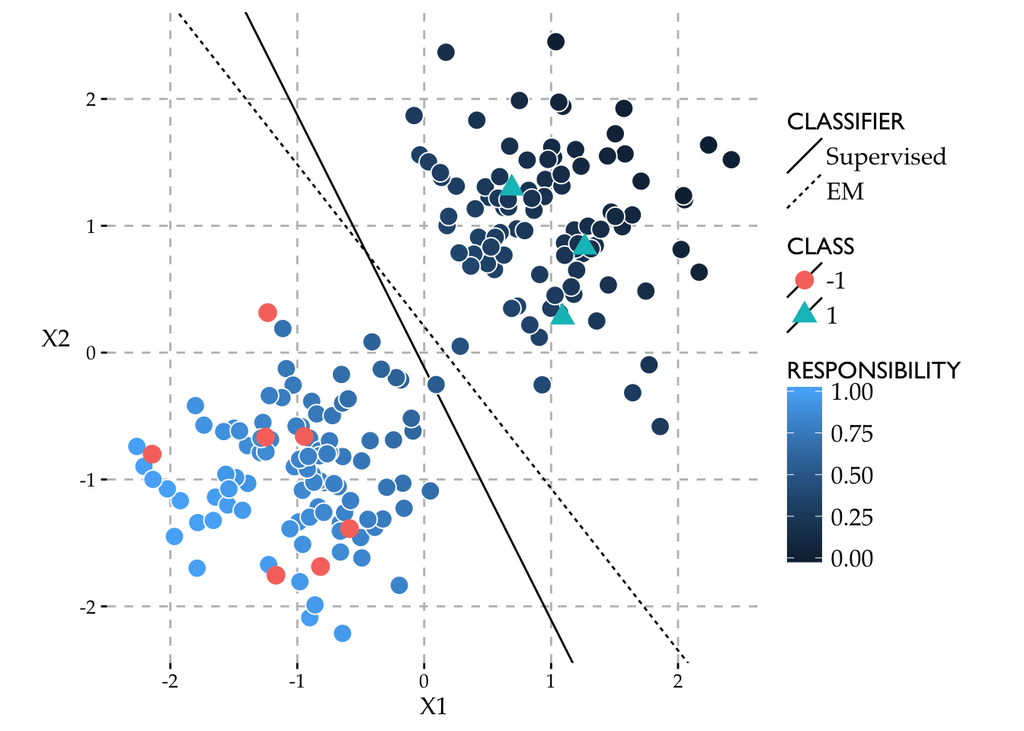